# Adolescent HIV Crisis: A Global Perspective

## Regional Analysis

In order to better understand regional patterns in adolescent HIV infections, we will look at differences between the world’s major regions. This is able to identify areas for focused interventions.

```
Region summary shape: (5, 3)
Regional bar chart created
```

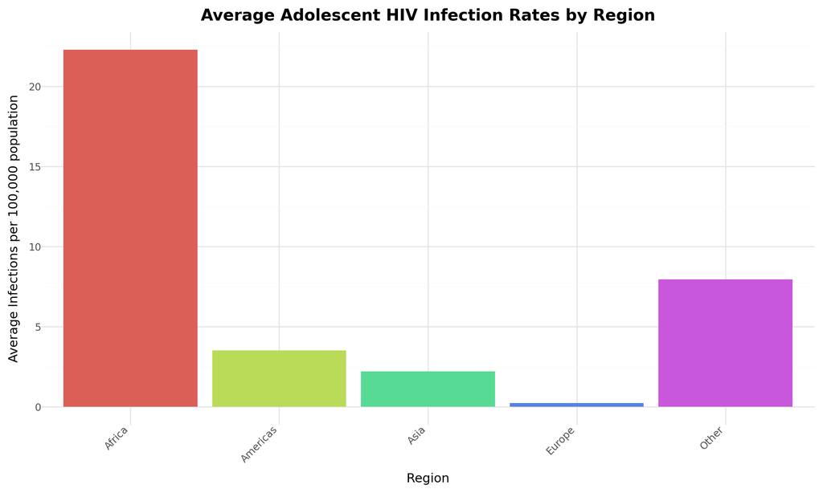

```python
#| label: regional-analysis
#| fig-cap: "Average Adolescent HIV Infection Rates by Region"
#| fig-alt: "Bar chart showing average HIV infection rates across different regions"

# Create a function to assign regions based on country names
def assign_region(country):
    africa = ['South Africa', 'Nigeria', 'Kenya', 'Ethiopia', 'Ghana', 'Tanzania',
              'Uganda', 'Zimbabwe', 'Zambia', 'Malawi', 'Botswana', 'Namibia', 'Angola']
    asia = ['India', 'China', 'Japan', 'Thailand', 'Indonesia', 'Vietnam',
            'Philippines', 'Malaysia', 'Pakistan', 'Bangladesh', 'Cambodia']
    europe = ['UK', 'France', 'Germany', 'Italy', 'Spain', 'Russia',
              'Sweden', 'Norway', 'Finland', 'Denmark', 'Poland', 'Ukraine']
    americas = ['United States', 'Canada', 'Brazil', 'Mexico', 'Argentina',
                'Chile', 'Peru', 'Colombia', 'Venezuela', 'Cuba']

    if any(c.lower() in country.lower() for c in africa):
        return 'Africa'
    elif any(c.lower() in country.lower() for c in asia):
        return 'Asia'
    elif any(c.lower() in country.lower() for c in europe):
        return 'Europe'
    elif any(c.lower() in country.lower() for c in americas):
        return 'Americas'
    else:
        return 'Other'

region_hiv = merged_data.copy()
region_hiv['region'] = region_hiv['country'].apply(assign_region)

# Summarize by region
region_summary = region_hiv.groupby('region').agg(
    avg_infection_rate=('infection_rate', 'mean'),
    total_countries=('country', 'count')
).reset_index()
print(f"Region summary shape: {region_summary.shape}")

# Create regional bar chart
if len(region_summary) > 0:
    bar_chart = (
        ggplot(region_summary, aes(x='region', y='avg_infection_rate', fill='region')) +
        geom_bar(stat='identity', show_legend=False) +
        labs(title='Average Adolescent HIV Infection Rates by Region',
            x='Region',
            y='Average Infections per 100,000 population') +
        theme_minimal() +
        theme(figure_size=(10, 6),
            plot_title=element_text(size=14, face='bold'),
            axis_text_x=element_text(angle=45, hjust=1))
    )
    print("Regional bar chart created")
else:
    print("No region data available for bar chart")
    # Create placeholder visualization
    bar_chart = (
        ggplot() +
        annotate("text", x=0, y=0, label="Insufficient data for regional analysis") +
        theme_minimal() +
        theme(figure_size=(10, 6))
    )

bar_chart
```

### Regional Disparities:

- The data reveals stark disparities in adolescent HIV infection rates across different regions
- Africa shows significantly higher average infection rates compared to other continents
- These patterns highlight the need for region-specific intervention strategies
- Understanding these regional differences is crucial for effective resource allocation and program design

## Geographic Distribution of HIV Infections

[figure not shown]

```python
plot_data = merged_data2.sort_values(by='infection_rate', ascending=True)

plt.figure(figsize=(10, 6))
plt.scatter(x=plot_data['country_raw'],
            y=plot_data['infection_rate'],
            s=plot_data['infection_rate'] * 10,  # Size proportional to rate
            alpha=0.6,
            color='skyblue',
            edgecolors='gray')

plt.title('Adolescent HIV Infection Rates (Bubble Size = Rate)')
plt.ylabel('HIV Infections per 100k')
plt.xlabel('Country')
plt.grid(True, linestyle='--', alpha=0.5)
plt.tight_layout()
plt.show()
```

## Correlation with Development Indicators

To understand the relationship between socioeconomic factors and HIV infection rates, we'll analyze correlations with key development indicators:

```
Scatter plot data points available: 87
Regression model fitted successfully

Regression Results:
===================================================================================
                      coef    std err          t      P>|t|      [0.025      0.975]
-----------------------------------------------------------------------------------
Intercept           5.8258      1.225      4.756      0.000       3.390       8.262
Life_expectancy    -0.1219      0.025     -4.883      0.000      -0.171      -0.072
log_GDP             0.4987      0.164      3.035      0.003       0.172       0.825
===================================================================================
```

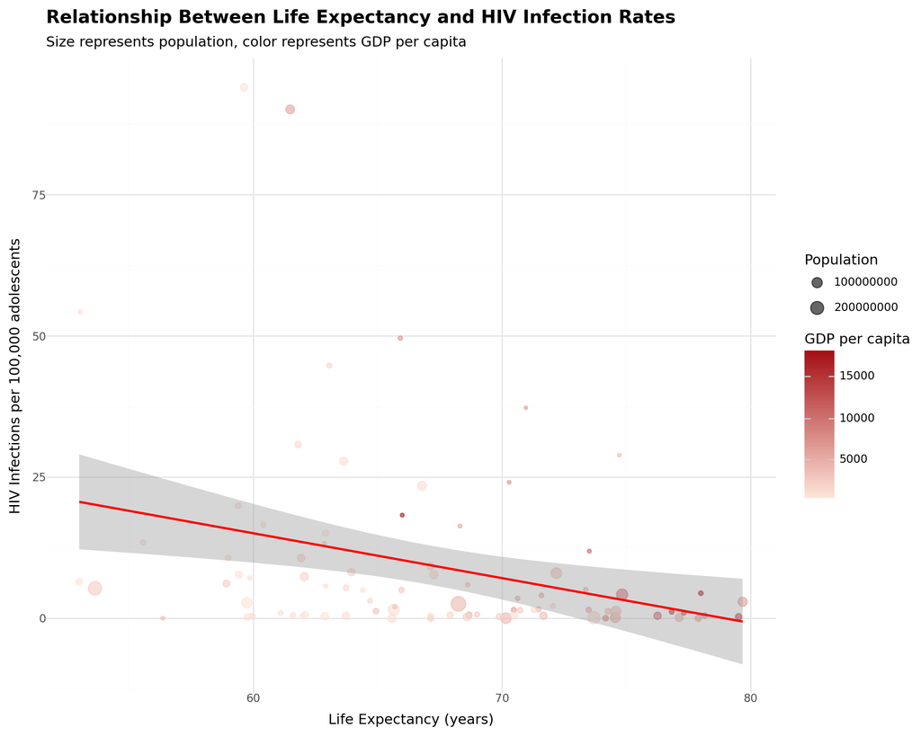

```python
#| label: correlation-analysis
#| fig-cap: "Relationship Between Life Expectancy and HIV Infection Rates"
#| fig-alt: "Scatter plot showing correlation between life expectancy and HIV infection rates"

# Ensure we have clean data for the scatter plot
scatter_data = merged_data.dropna(subset=['Life_expectancy', 'infection_rate'])
print(f"Scatter plot data points available: {len(scatter_data)}")

# Improved regression analysis with log transformation
if len(scatter_data) > 5:  # Need meaningful number of points for regression
    try:
        # Log transformation for better fit
        scatter_data['log_infection_rate'] = np.log1p(scatter_data['infection_rate'])
        scatter_data['log_GDP'] = np.log1p(scatter_data['GDP_per_capita'])

        # Fit regression model
        model = ols('log_infection_rate ~ Life_expectancy + log_GDP', data=scatter_data).fit()
        print("Regression model fitted successfully")

        # Add predictions to data frame
        scatter_data['predicted_rate'] = np.expm1(model.predict(scatter_data))

        # Print regression results
        print("\nRegression Results:")
        print(model.summary().tables[1])  # Print just the coefficient table
    except Exception as e:
        print(f"Error in regression analysis: {e}")
        scatter_data['predicted_rate'] = scatter_data['infection_rate']  # Use actual rate as fallback
else:
    print("Not enough complete data for regression analysis")
    scatter_data['predicted_rate'] = scatter_data['infection_rate']  # Use actual rate as fallback

# Create scatter plot with linear trend line
if len(scatter_data) > 5:
    scatter_plot = (
        ggplot(scatter_data, aes(x='Life_expectancy', y='infection_rate')) +
        geom_point(aes(size='Population', color='GDP_per_capita'), alpha=0.6) +
        geom_smooth(method='lm', color='red', se=True) +
        scale_size_continuous(name='Population') +
        scale_color_gradient(low='#fee5d9', high='#a50f15', name='GDP per capita') +
        labs(title='Relationship Between Life Expectancy and HIV Infection Rates',
             subtitle='Size represents population, color represents GDP per capita',
             x='Life Expectancy (years)',
             y='HIV Infections per 100,000 adolescents') +
        theme_minimal() +
        theme(figure_size=(10, 8),
              plot_title=element_text(size=14, face='bold'))
    )
else:
    # Create a simplified scatter plot with available data
    scatter_plot = (
        ggplot(merged_data, aes(x='Life_expectancy', y='infection_rate')) +
        geom_point(color='blue') +
        labs(title='Relationship Between Life Expectancy and HIV Infection Rates',
             x='Life Expectancy (years)',
             y='HIV Infections per 100,000 adolescents') +
        theme_minimal() +
        theme(figure_size=(10, 8))
    )

scatter_plot
```

## Temporal Trends

Finally, we'll examine how adolescent HIV infections have changed over time to understand progress and identify trends:

```
Time series data shape: (14, 2)
Time series chart created
```

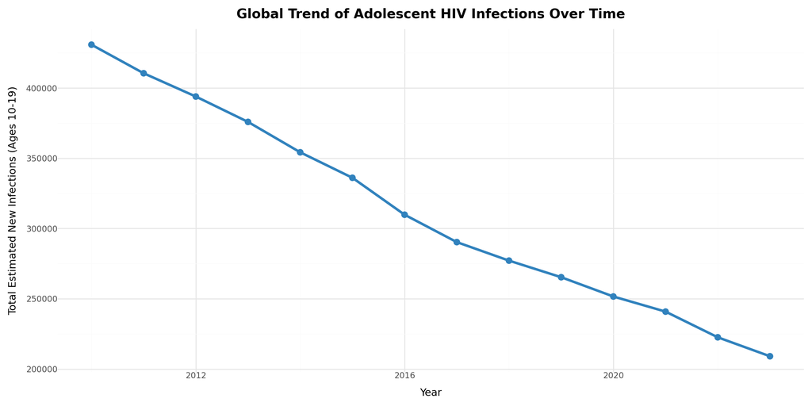

```python
#| label: time-series
#| fig-cap: "Global Trend of Adolescent HIV Infections Over Time"
#| fig-alt: "Line chart showing trends in adolescent HIV infections over time"

# Time series analysis
time_series = country_year_hiv.groupby('time_period').agg(
    global_infections=('total_infections', 'sum')
).reset_index()
print(f"Time series data shape: {time_series.shape}")

# Create time series visualization
if len(time_series) > 1:
    time_chart = (
        ggplot(time_series, aes(x='time_period', y='global_infections')) +
        geom_line(color='#3182bd', size=1.5) +
        geom_point(color='#3182bd', size=3) +
        labs(title='Global Trend of Adolescent HIV Infections Over Time',
            x='Year',
            y='Total Estimated New Infections (Ages 10-19)') +
        theme_minimal() +
        theme(figure_size=(12, 6),
            plot_title=element_text(size=14, face='bold'))
    )
    print("Time series chart created")
else:
    print("Insufficient data for time series chart")
    time_chart = (
        ggplot() +
        annotate("text", x=0, y=0, label="Insufficient data for time series analysis") +
        theme_minimal() +
        theme(figure_size=(12, 6))
    )

time_chart
```

## Countries Most in Need

Identifying countries with the highest burden of adolescent HIV infections helps prioritize interventions and resource allocation:

```
Top countries chart created
```

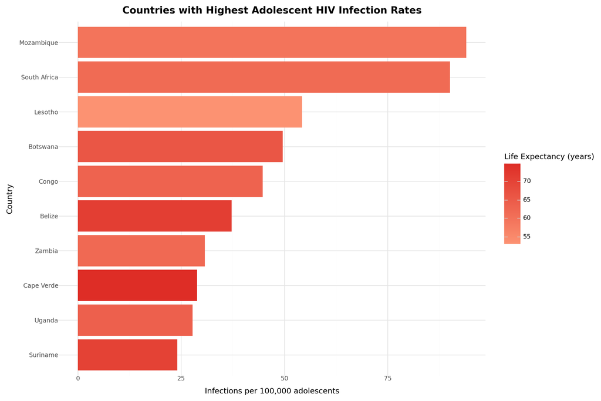

```python
#| label: high-burden-countries
#| fig-cap: "Countries with Highest Adolescent HIV Infection Rates"
#| fig-alt: "Bar chart showing countries with highest HIV infection rates"

# Create visualization of top countries
if len(merged_data) >= 10:
    top_countries = merged_data.sort_values('infection_rate', ascending=False).head(10)
    top_countries_chart = (
        ggplot(top_countries, aes(x='reorder(country, infection_rate)', y='infection_rate', fill='Life_expectancy')) +
        geom_bar(stat='identity') +
        scale_fill_gradient(low='#fc9272', high='#de2d26', name='Life Expectancy (years)') +
        labs(title='Countries with Highest Adolescent HIV Infection Rates',
            x='Country',
            y='Infections per 100,000 adolescents') +
        coord_flip() +
        theme_minimal() +
        theme(figure_size=(12, 8),
            plot_title=element_text(size=14, face='bold'))
    )
    print("Top countries chart created")
else:
    print("Insufficient data for top countries chart")
    top_countries_chart = (
        ggplot() +
        annotate("text", x=0, y=0, label="Insufficient data for top countries analysis") +
        theme_minimal() +
        theme(figure_size=(12, 8))
    )

top_countries_chart
```

### Priority Countries:

- The chart identifies the countries with the highest adolescent HIV infection rates
- These countries should be prioritized for targeted interventions and increased resource allocation
- The visualization also reveals the relationship between lower life expectancy (lighter colors) and higher HIV infection rates
- Special attention should be given to countries that have both high infection rates and lower life expectancy

# Conclusion and Recommendations

An analysis of UNICEF adolescent HIV infections data shows that there are significant global disparities which correlate well with socioeconomic factors. There has been progress but many challenges and especially in Sub-Saharan Africa remain.

## Recommendations

Based on our analysis, we recommend:

- **Targeted Interventions:** Focus resources on high-burden countries identified in this report.
- **Integrated Approach:** Address HIV alongside broader socioeconomic development initiatives.
- **Adolescent-Specific Programs:** Prevention and treatment programs developed with emphasis in meeting adolescents' specific need and challenge.
- **Improved Data Collection:** Improve systems for tracking of adolescent HIV infections to address data gaps in this analysis.
- **Policy Advocacy:** These findings can be used by you as a mobilizing force for greater attention and resources given for adolescent HIV prevention and control.

## Next Steps

- Conduct deeper country-level analyses to understand specific drivers of adolescent HIV infections
- Evaluate existing intervention programs in high-burden countries
- Develop region-specific strategies based on the disparities identified
- Monitor trends with updated data as it becomes available

# Bibliography

- Guilamo-Ramos, V., Flores, D.D., Randolph, S.D. and Etogho, E.B.A., 2021. Nursing contributions to ending the global adolescent and young adult HIV pandemic. Journal of the Association of Nurses in AIDS Care, 32(3), pp.264-282.
- Roberts, K.J., Smith, C., Cluver, L., Toska, E. and Sherr, L., 2021. Understanding mental health in the context of adolescent pregnancy and HIV in Sub-Saharan Africa: a systematic review identifying a critical evidence gap. AIDS and Behavior, 25, pp.2094-2107.
- Obeagu, E.I., Obeagu, G.U., Ede, M.O., Odo, E.O. and Buhari, H.A., 2023. Translation of HIV/AIDS knowledge into behavior change among secondary school adolescents in Uganda: A review. Medicine, 102(49), p.e36599.
- Benton, T.D., Boyd, R.C. and Njoroge, W.F., 2021. Addressing the global crisis of child and adolescent mental health. JAMA pediatrics, 175(11), pp.1108-1110.
- Roberts, K.J., Smith, C., Cluver, L., Toska, E., Zhou, S., Boyes, M. and Sherr, L., 2022. Adolescent motherhood and HIV in South Africa: Examining prevalence of common mental disorder. AIDS and Behavior, pp.1-14.